# Sepp1

Team Le Grand

24 mars,2022

## I-Analyse RNAseq old vs young

### I.1-Sepp1 significant differentially expressed

Sepp1 is differentially expressed in **FAPs(FibroAdipogenic Progenitors)** in **D0,D2 and D7** , slightly **UP** expressed in old mice.

Sepp1 is differentially expressed in **Macrophage-2** in **D2, D4 and D7** , slightly **UP** expressed in **D2** then slightly **DOWN** expressed in old mice.

And Sepp1 is differentially expressed in **MuSCs(Muscles Stem Cells)** in **D2**, slightly **UP** expressed in old mice.

### I.2- Significant Genes Set Enrichment Analysis (GSEA) results

Sepp1 participates in the upstream enrichment of the pathways of PLATELET ACTIVATION SIGNALING AND AGGREGATION, RESPONSE TO ELEVATED PLATELET CYTOSOLIC CA2 in sCs in D2

### I.2-All data old vs young , each time point and each type cell

|  | symbol | type | day | age | meancountnormalised | log2FoldChange | pvalue | padj |
| --- | --- | --- | --- | --- | --- | --- | --- | --- |
| 1 | Selenop | ECs | D0 | Old | 4702.74480964093 | -0.00376445569827756 | 0.801457836223303 | 0.999987024176371 |
| 2 | Selenop | ECs | D2 | Old | 1694.93772161411 | -0.00271777796793477 | 0.119838963276514 | 0.99907937632229 |
| 3 | Selenop | ECs | D4 | Old | 2988.486 | -0.0890605228719422 | 0.186806127059842 | 0.674391883537434 |
| 4 | Selenop | ECs | D7 | Old | 3796.201 | -0.153322260155098 | 0.0545085157573916 | 0.395603289033995 |
| 5 | Selenop | ECs | D0 | Young | 4809.64895732079 | -0.00376445569827756 | 0.801457836223303 | 0.999987024176371 |
| 6 | Selenop | ECs | D2 | Young | 1991.42507077558 | -0.00271777796793477 | 0.119838963276514 | 0.99907937632229 |
| 7 | Selenop | ECs | D4 | Young | 3356.851 | -0.0890605228719422 | 0.186806127059842 | 0.674391883537434 |
| 8 | Selenop | ECs | D7 | Young | 4441.336 | -0.153322260155098 | 0.0545085157573916 | 0.395603289033995 |
| 9 | Selenop | FAPs | D0 | Old | 10027.322793329 | 0.304161344972835 | 0.00109979406256635 | 0.0355834250771744 |
| 10 | Selenop | FAPs | D2 | Old | 2050.09353078139 | 0.360283479647398 | 0.000727454292108442 | 0.0465669496400821 |

[output cut: 26 more lines]

### I.3-Plots old vs young , each time point and each type cell

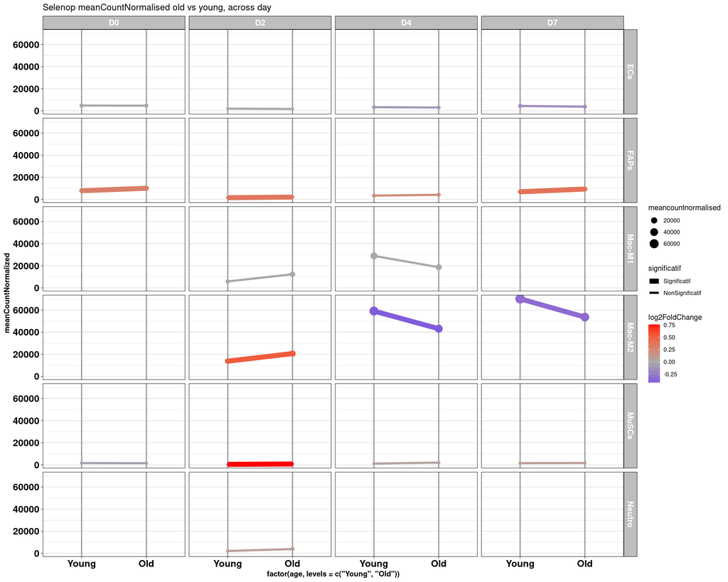

## II-Analyse RNAseq over the regeneration

### II.1-In Young condition : Sepp1 significant differentially expressed

In **ECs** , **FAPs** between each time point the expression of Selenop is significant differentially expressed , first decrease post injury (between D0 and D2) then increase during regeneration ( between D2 and D4 and D4 and D7)

In **MuSCs** the expression decrease too in post injury and increase after, but the increase is over in D4. No difference between D4 and D7

In **M1** and **M2** the expression increase strongly between D2 and D4

### II.2-In Old condition : Sepp1 significant differentially expressed

In ECs the expression of Sepp1 decrease increase in post injury then increase as quickly after. In D4 th expression of Sepp1 almost comme back to their basal level

In FAPs like ECS the expression decrease post injury but the come back to basal level is more slow.

In MuSCs like ECS and FAPs the expression decrease post injury and after we dont sure ,there are a lake of power to be sure between D2 and D4

|  | Old.MuSCs.D2_1 | Old.MuSCs.D2_2 | Old.MuSCs.D4_2 | Old.MuSCs.D4_1 | symbol |
| --- | --- | --- | --- | --- | --- |
| ENSMUSG00000064373 | 724.7161 | 649.5926 | 3203.676 | 652.9791 | Selenop |

In M2 the expression increase strongly between D2 and D4

### II.3-All data in young and odl t+1 vs t

|  | symbol | type | TimeCondtion | age | meancountnormalised_t | meancountnormalised_t.1 | log2FoldChange | pvalue | padj |
| --- | --- | --- | --- | --- | --- | --- | --- | --- | --- |
| 1 | Selenop | ECs | D0_D2 | Old | 4878.3770927585 | 1683.02827195745 | -1.51759935678914 | 6.82457583296558e-35 | 1.68694983871118e-32 |
| 2 | Selenop | ECs | D0_D2 | Young | 4801.60760906517 | 1918.01745324306 | -1.29930765260262 | 1.78395607147237e-18 | 7.65022245934384e-17 |
| 3 | Selenop | ECs | D2_D4 | Old | 1545.72211411295 | 3081.06025724296 | 0.938008499576129 | 3.90817914522546e-09 | 2.23751072422448e-06 |
| 4 | Selenop | ECs | D2_D4 | Young | 1904.71909360526 | 3597.90944693871 | 0.889728229978937 | 4.64338551768823e-14 | 7.8473215248931e-12 |
| 5 | Selenop | ECs | D4_D7 | Old | 2968.05744536807 | 3647.09079267541 | 0.213381161291182 | 0.0210541995920607 | 0.226554314520349 |
| 6 | Selenop | ECs | D4_D7 | Young | 3483.53797382795 | 4478.23145245412 | 0.304440566841933 | 0.00201901965269753 | 0.0430890517842559 |
| 7 | Selenop | FAPs | D0_D2 | Old | 11811.6305124644 | 2036.08734811062 | -2.53134803991816 | 8.30409786963408e-196 | 6.35452216524044e-193 |
| 8 | Selenop | FAPs | D0_D2 | Young | 7835.4020675706 | 1256.17049930733 | -2.62735432190576 | 1.06115983099893e-66 | 1.94769991647459e-64 |
| 9 | Selenop | FAPs | D2_D4 | Old | 2024.47923851445 | 4184.3514185589 | 1.033219682887 | 2.93759702404843e-26 | 3.67384673487884e-24 |
| 10 | Selenop | FAPs | D2_D4 | Young | 1477.04681070475 | 3402.25058682295 | 1.1818333757281 | 9.00603106620008e-19 | 3.25304406871833e-17 |

[output cut: 14 more lines]

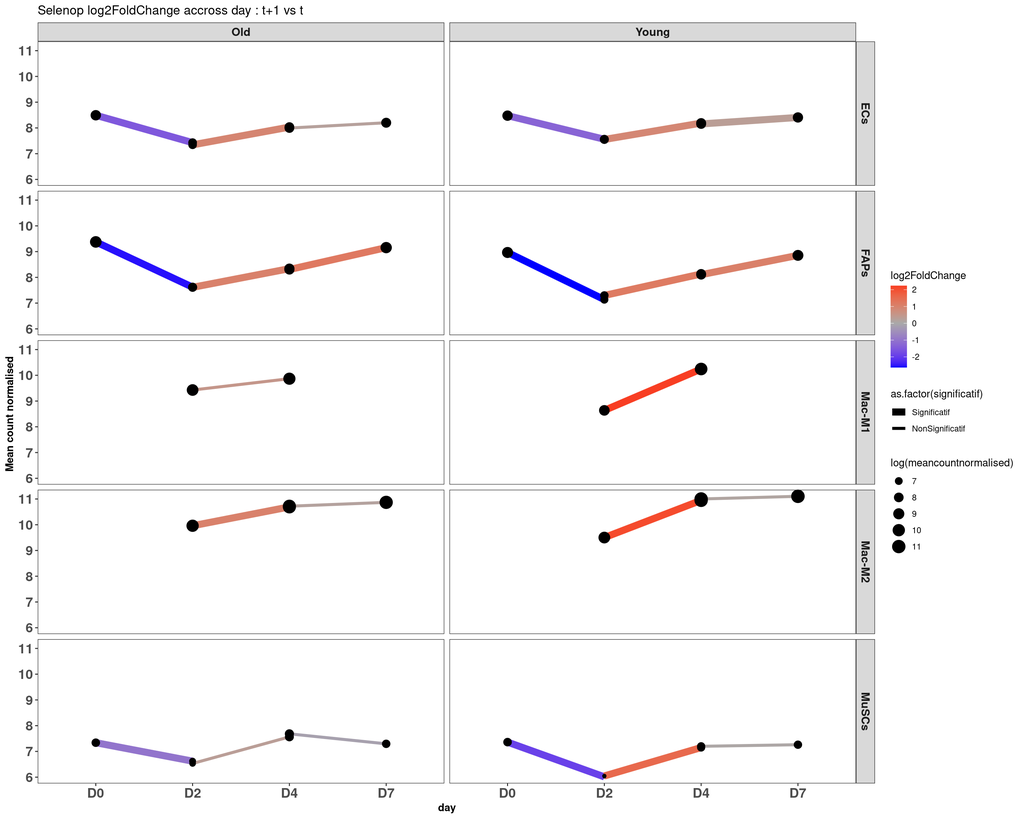

## III-Old vs Young over the regeneration

### III.1-Old vs Young : Sepp1 significant differentially expressed

Between day 4 and day 7 , Odl expression of Sepp1 in FAPs is a little stronger.

Between day 4 and day 7 , Odl expression of Sepp1 in M2 is a little lower

Between day 0 and day 2 , Odl expression of Sepp1 in MuSCs is a little stronger.

### III.3-All data old vs young, between t and t+1

|  | symbol | type | TimeCondtion | age | meancountnormalised_t | meancountnormalised_t.1 | log2FoldChange | pvalue | padj |
| --- | --- | --- | --- | --- | --- | --- | --- | --- | --- |
| 1 | Selenop | ECs | D0_D2 | Young | 0.863001346845746 | -0.889490736459473 | -0.0439039480599581 | 0.126374440681432 | 0.874316415519866 |
| 2 | Selenop | ECs | D0_D2 | Old | 0.830062900025025 | -1.20536026561695 | -0.0439039480599581 | 0.126374440681432 | 0.874316415519866 |
| 3 | Selenop | ECs | D2_D4 | Old | -1.24591917286126 | 0.646073717435997 | -0.0723596678771037 | 0.225503237428124 | 0.694554446112807 |
| 4 | Selenop | ECs | D2_D4 | Young | -0.800624645283303 | 0.985163709754808 | -0.0723596678771037 | 0.225503237428124 | 0.694554446112807 |
| 5 | Selenop | ECs | D4_D7 | Old | -0.950533608588307 | 0.20311498637548 | -0.12051484363984 | 0.0856168193981903 | 0.533112041095871 |
| 6 | Selenop | ECs | D4_D7 | Young | -0.297179607670732 | 1.04459822988357 | -0.12051484363984 | 0.0856168193981903 | 0.533112041095871 |
| 7 | Selenop | FAPs | D0_D2 | Old | 1.06793158319004 | -0.777174340577868 | 0.340503085071213 | 0.00113592491462226 | 0.0679421989326687 |
| 8 | Selenop | FAPs | D0_D2 | Young | 0.810591288926803 | -1.10134853153898 | 0.340503085071213 | 0.00113592491462226 | 0.0679421989326687 |
| 9 | Selenop | FAPs | D2_D4 | Old | -0.532750284467365 | 1.10698189558153 | 0.182528737803598 | 0.023223194866647 | 0.262216326848723 |
| 10 | Selenop | FAPs | D2_D4 | Young | -1.23479216752127 | 0.660560556407109 | 0.182528737803598 | 0.023223194866647 | 0.262216326848723 |

[output cut: 14 more lines]